# M2 Visualisation d’informations sur R

# 2 Exercice 2

L’enquête annuelle “Besoins en Main-d’Œuvre” est, depuis plusieurs années, un élément essentiel de connaissance du marché du travail. Chaque année, Pôle emploi adresse un questionnaire à plus de 1,6 million d’établissements afin de connaître leurs besoins en recrutement par secteur d’activité et par bassin d’emploi.

Cette enquête permet entre autre :  
* d’anticiper les difficultés de recrutement; * d’améliorer l’orientation des demandeurs d’emploi vers des formations ou des métiers en adéquation avec les besoins du marché du travail;  
* d’informer les demandeurs d’emploi sur l’évolution de leur marché du travail et les métiers porteurs.

Les données sont disponibles à l’adresse suivante: https://www.data.gouv.fr/fr/datasets/enquete-besoins-en-main-doeuvre-bmo/

```r
library(readxl)
ResMetBE17 <- read_excel("../Elements/data/ResMetBE17.xlsx",sheet = "ResMetBe17")
View(ResMetBE17)
```

1. Réaliser un diagramme en barre pour comptabiliser les projets de recrutement par famille de métier

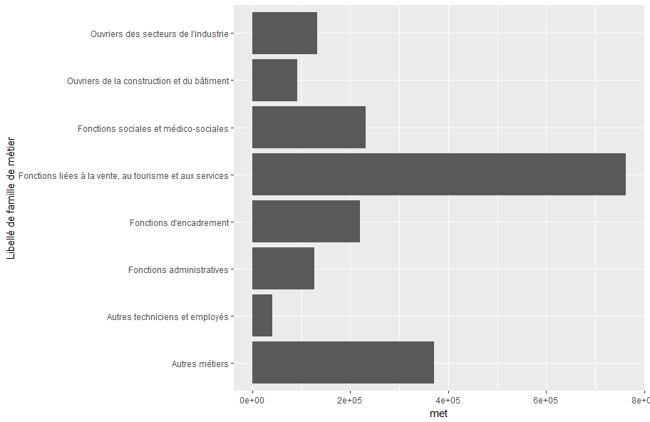

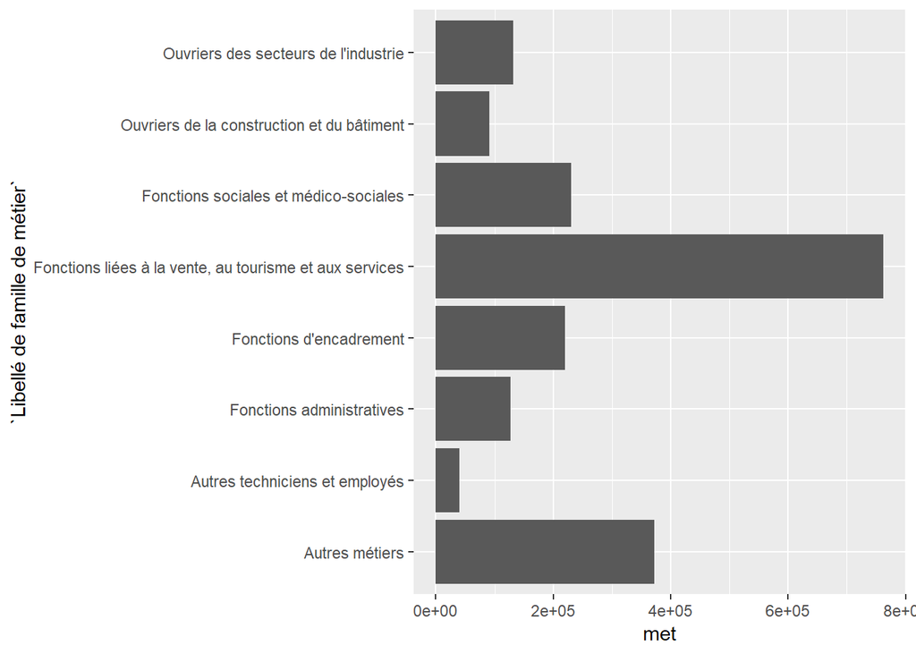

```r
library(ggplot2)
g1<-ggplot(ResMetBE17, aes(`Libellé de famille de métier`,met))+
  geom_bar(stat="identity")+
  coord_flip()
g1
```

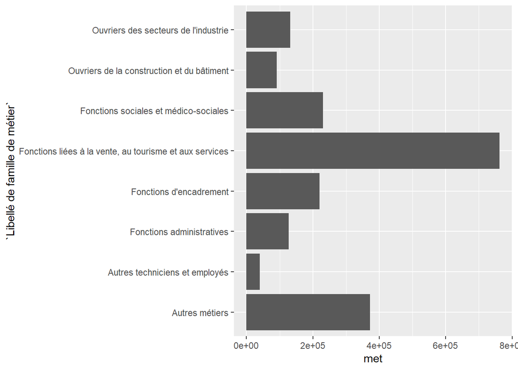

```r
#seconde possibilité

g1_bis<-ggplot(ResMetBE17, aes(`Libellé de famille de métier`,met))+
  geom_bar(stat="summary",fun.y = "sum")+
  coord_flip()
g1_bis
```

2. Apporter des modifications pour un rendu plus esthétique

[figure not shown]

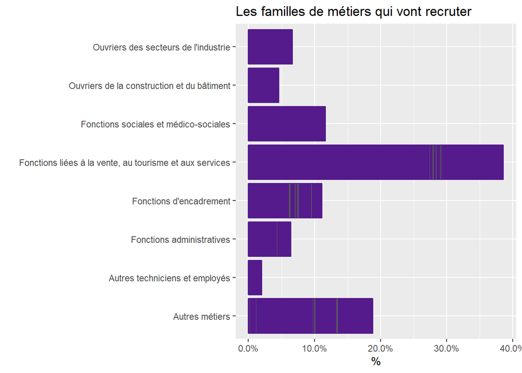

```r
g2<-ggplot(ResMetBE17, aes(x=`Libellé de famille de métier`,y=met/sum(met)))+
  geom_bar(stat="identity", color="purple4")+
  scale_y_continuous(labels = scales::percent)+
  coord_flip()+
  labs(title="Les familles de métiers qui vont recruter",
       x='',
       y='%')
g2
```

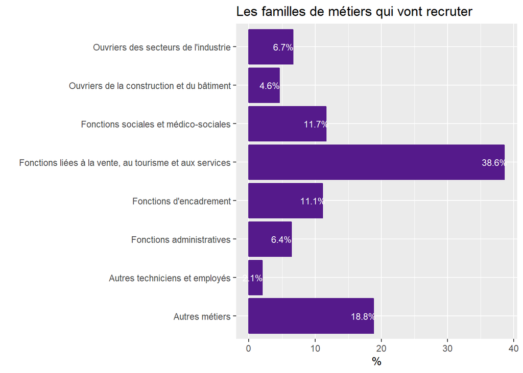

```r
#seconde possibilité

library(dplyr)
data_met<-ResMetBE17%>%
  group_by(`Libellé de famille de métier`)%>%
  summarise(met=sum(met))%>%
  ungroup()%>%
  mutate(pct = prop.table(met) * 100)

g2_bis<- data_met%>%
  ggplot(aes(x=`Libellé de famille de métier`, y = pct)) +
  geom_bar(stat = 'identity', fill="purple4",color="purple4") +
  geom_text(aes(y = pct -1.5 ,
                label = paste0(round(pct,1), '%')),
            position = position_dodge(width = .9),
            size = 3,
            color="#FFFFFF")+
  coord_flip()+
  labs(title="Les familles de métiers qui vont recruter",
       x='',
       y='%')

g2_bis
```

3. Transformer ce graphique en diagramme sectoriel

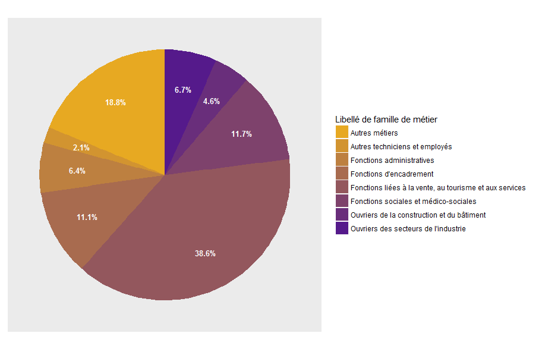

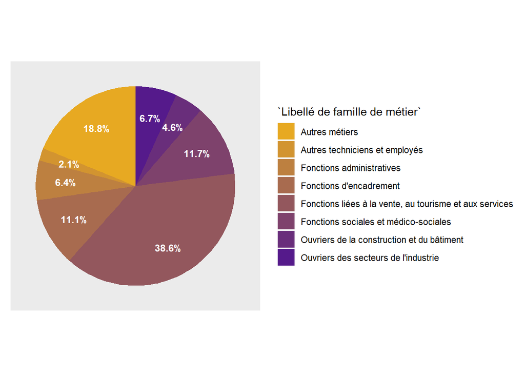

```r
  data_cam<-ResMetBE17%>%
    group_by(`Libellé de famille de métier`)%>%
    summarise(met=sum(met))%>%
    ungroup()%>%
    mutate(pct = prop.table(met) * 100,
           somcum=cumsum(pct),
           rsomcum=rev(cumsum(rev(pct))),
           milieu=rsomcum-pct/2,
           labels=paste0(round(pct,1), '%'))

g3<- data_cam%>%
  ggplot(aes(x='', y = pct,fill=`Libellé de famille de métier`)) +
  geom_bar(stat = 'identity',width = 1)+
  coord_polar(theta = "y",start = 0)+
  geom_text(aes(x=1.2, y=milieu,label=labels),
          color="#FFFFFF",
          fontface="bold",
          size=3.3
          )+
  theme(
    axis.text.x=element_blank(),
    axis.title.x = element_blank(),
    axis.title.y = element_blank(),
    panel.border = element_blank(),
    panel.grid=element_blank(),
    axis.ticks = element_blank(),
    plot.title=element_text(size=14, face="bold",hjust = 0.5, color='#797979')
    )+
  scale_fill_manual(values=colorRampPalette(c("#E7A922", "purple4"))(nrow(data_cam)))



g3
```

4. Réaliser un nuage de point (projet X difficulté) où les axes horizontaux et verticaux correspondent aux médianes des variables.

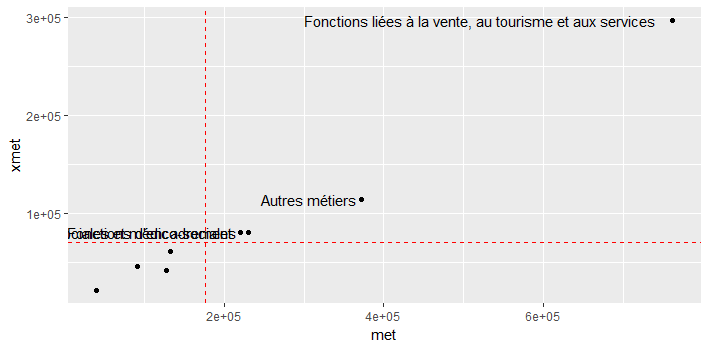

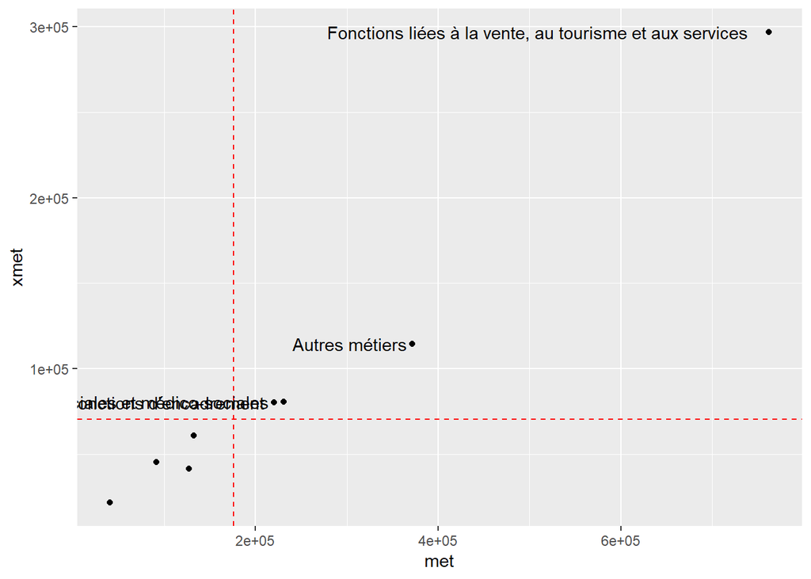

```r
Data_Nuage<-
  ResMetBE17%>%
  select(`Libellé de famille de métier`,met,xmet,smet)%>%
  group_by(`Libellé de famille de métier`)%>%
  summarise_at(vars(met,xmet,smet),funs(sum))

g4<-ggplot(Data_Nuage, aes(x=met, y=xmet))+
  geom_point()+
  geom_hline(yintercept=Data_Nuage$xmet%>%quantile(0.5), linetype="dashed", color = "red")+
  geom_vline(xintercept=Data_Nuage$met%>%quantile(0.5), linetype="dashed", color = "red")+
  geom_text(data=Data_Nuage%>%filter(met>met%>%quantile(0.5) & xmet>xmet%>%quantile(0.5)),
            aes(label=`Libellé de famille de métier`),
            hjust=1.05)

g4
```

5. Sur R il est possible d’améliorer la visibilité des labels en utilisant la fonction geom_text_repel du package ggrepel pour obtenir un graphique du type suivant :

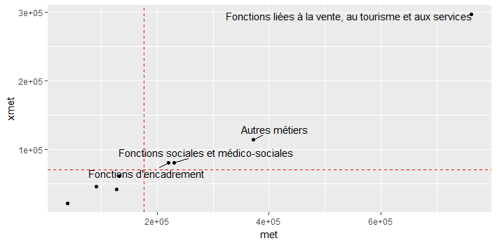

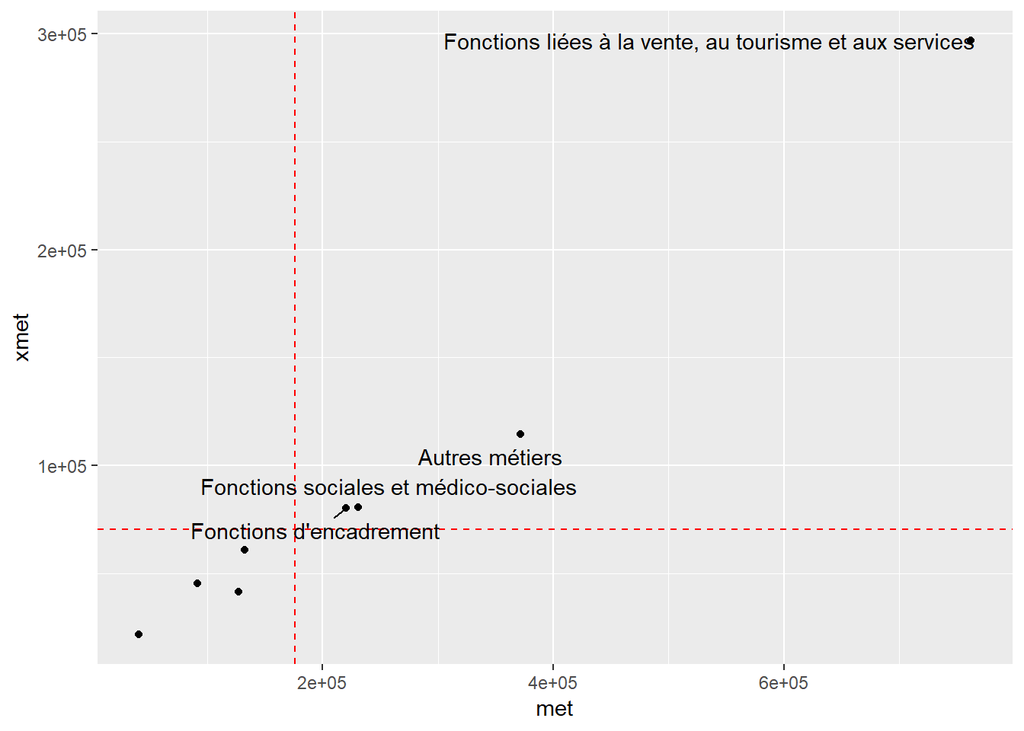

```r
library(ggrepel)
g4bis<-ggplot(Data_Nuage, aes(x=met, y=xmet))+
  geom_point()+
  geom_hline(yintercept=Data_Nuage$xmet%>%quantile(0.5), linetype="dashed", color = "red")+
  geom_vline(xintercept=Data_Nuage$met%>%quantile(0.5), linetype="dashed", color = "red")+
  geom_text_repel(data=Data_Nuage%>%filter(met>met%>%quantile(0.5) & xmet>xmet%>%quantile(0.5)),
                  aes(label=`Libellé de famille de métier`),
                  box.padding = unit(0.45, "lines"))

g4bis
```

6. Deux métiers vous intéressent particulièrement :
- M2Z90 - Ingénieurs et cadres d’études, R et D en informatique, chefs de projets informatiques
- N0Z90 - Ingénieurs et cadres d’études, recherche et développement (industrie)

Dans quelles régions se situent les projets de recrutement les plus nombreux ?

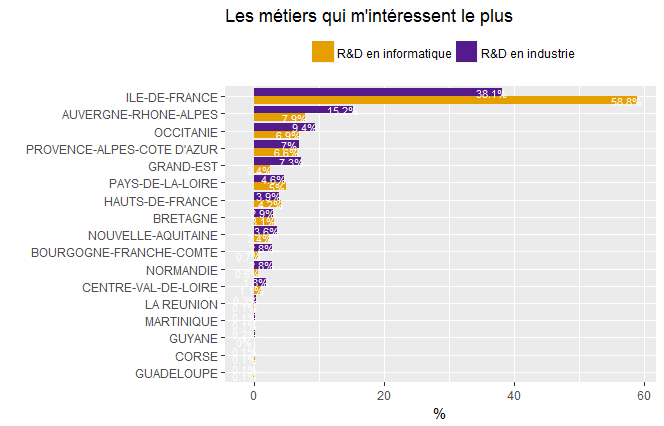

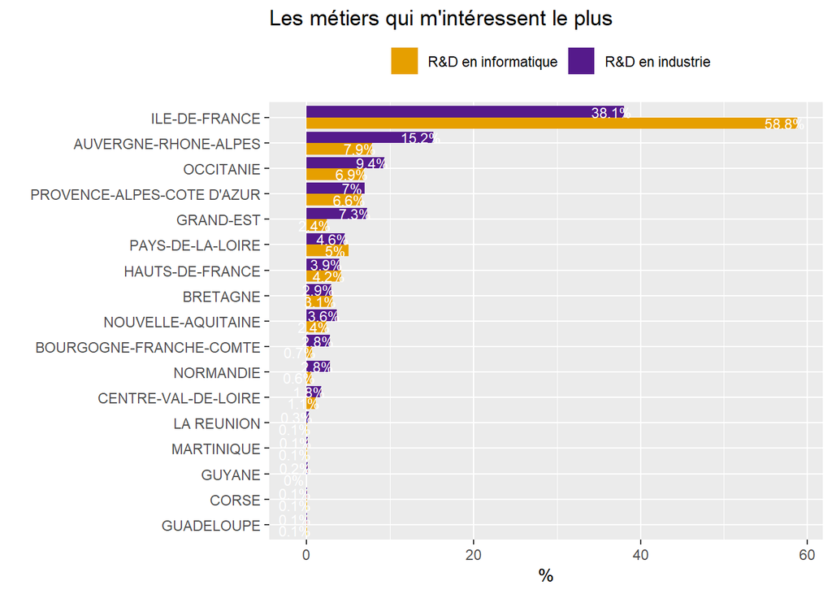

```r
Data_Met_Int<-
  ResMetBE17%>%
  select(`code métier BMO`,`nom_metier BMO`,REG,NOM_REG,met)%>%
  filter(`code métier BMO` %in% c("M2Z90","N0Z90"))%>%
  group_by(`code métier BMO`,`nom_metier BMO`,REG,NOM_REG)%>%
  summarise_at(vars(met),funs(sum))%>%
  ungroup()%>%
  group_by(`code métier BMO`,`nom_metier BMO`)%>%
  mutate(pct = prop.table(met) * 100)


g5<- Data_Met_Int%>%
  ggplot(aes(x=reorder(NOM_REG,pct), y = pct,fill=`nom_metier BMO`))+
  geom_bar(stat = 'identity',position = "dodge") +
  geom_text(aes(y = pct -1.5 ,
                label = paste0(round(pct,1), '%')),
            position = position_dodge(width = .9),
            size = 3,
            color="#FFFFFF")+
  coord_flip()+
  labs(title="Les métiers qui m'intéressent le plus",
       x='',
       y='%')+
  scale_fill_manual(values=c("#E69F00", "purple4"),
                    name="",
                    labels=c("R&D en informatique", "R&D en industrie"))+
  theme(legend.position="top")

g5
```

7. Représenter par une infographie la part des projets de recrutement jugés difficiles

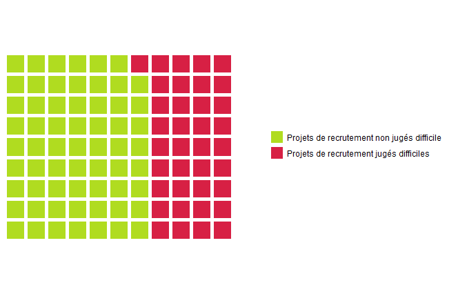

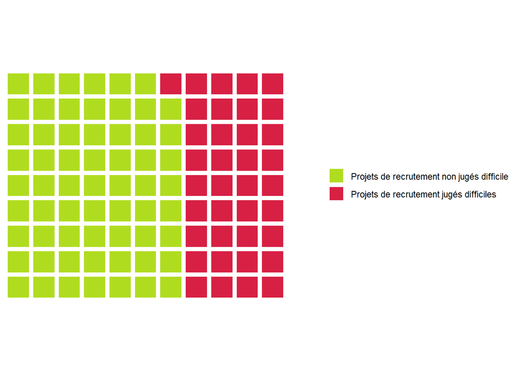

```r
library(waffle)


part_diff<-c("Projets de recrutement non jugés difficile"=(sum(ResMetBE17$met)-sum(ResMetBE17$xmet))/sum(ResMetBE17$met)*100,
"Projets de recrutement jugés difficiles"=sum(ResMetBE17$xmet)/sum(ResMetBE17$met)*100)
waffle(part_diff, rows=9, colors=c("#B0DC20", "#D72044"))
```

8. Réaliser une typologie des régions françaises prenant en compte les projets de recrutement, les projets de recrutement jugés difficiles, les projets de recrutement saisonniers par famille de métiers

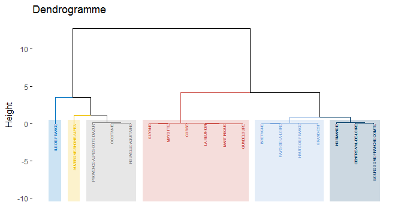

[figure not shown]

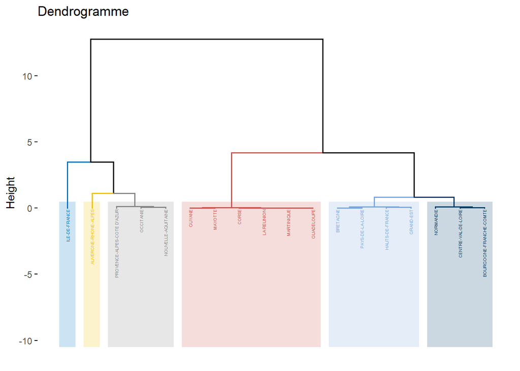

```r
library(FactoMineR)
library(factoextra)
library(tidyr)

data_typo_met<-ResMetBE17%>%
  select(`Famille_metier`,NOM_REG,met)%>%
  group_by(`Famille_metier`,NOM_REG)%>%
  summarise_at(vars(met),funs(sum))%>%
  ungroup()%>%
  spread(`Famille_metier`,met)

nom_col_met<-paste(colnames(data_typo_met)[2:ncol(data_typo_met)],"_met",sep="")
colnames(data_typo_met)[2:ncol(data_typo_met)]<-nom_col_met

data_typo_xmet<-ResMetBE17%>%
  select(`Famille_metier`,NOM_REG,xmet)%>%
  group_by(`Famille_metier`,NOM_REG)%>%
  summarise_at(vars(xmet),funs(sum))%>%
  ungroup()%>%
  spread(`Famille_metier`,xmet)

nom_col_xmet<-paste(colnames(data_typo_xmet)[2:ncol(data_typo_xmet)],"_xmet",sep="")
colnames(data_typo_xmet)[2:ncol(data_typo_xmet)]<-nom_col_xmet

data_typo<-left_join(data_typo_met,data_typo_xmet,by="NOM_REG")

data_typo_smet<-ResMetBE17%>%
  select(`Famille_metier`,NOM_REG,smet)%>%
  group_by(`Famille_metier`,NOM_REG)%>%
  summarise_at(vars(smet),funs(sum))%>%
  ungroup()%>%
  spread(`Famille_metier`,smet)

nom_col_smet<-paste(colnames(data_typo_smet)[2:ncol(data_typo_smet)],"_smet",sep="")
colnames(data_typo_smet)[2:ncol(data_typo_smet)]<-nom_col_smet

data_typo<-left_join(data_typo,data_typo_smet,by="NOM_REG")
data_typo<-data.frame(data_typo)
rownames(data_typo)<-data_typo$NOM_REG
data_typo<-data_typo[,2:ncol(data_typo)]

# 1. ACP
res.pca <- PCA(data_typo, ncp = 3, graph = FALSE)
# 2. HCPC
res.hcpc <- HCPC(res.pca, graph = FALSE)

#Visualiser le dendrogramme généré par la classification. Fonction R: fviz_dend() [factoextra]:

fviz_dend(res.hcpc,
          cex = 0.3,                     # Taille du text
          palette = "jco",               # Palette de couleur ?ggpubr::ggpar
          rect = TRUE, rect_fill = TRUE, # Rectangle autour des groupes
          rect_border = "jco",           # Couleur du rectangle
          labels_track_height = 10,     # Augment l'espace pour le texte
          main="Dendrogramme")
```

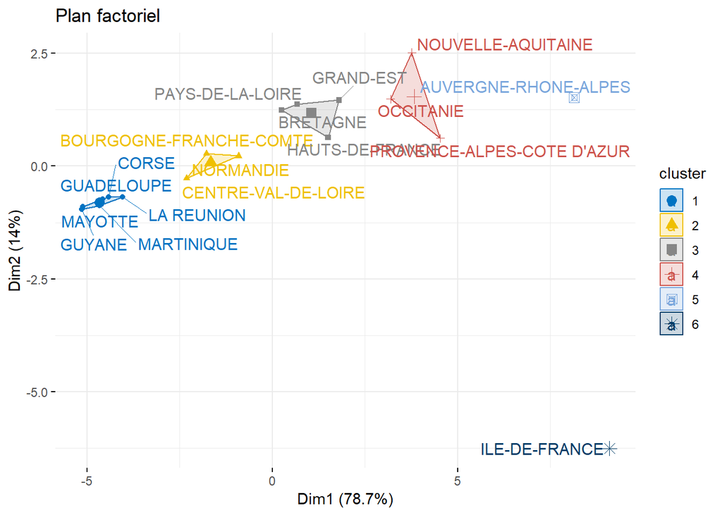

```r
#Visualiser les individus et colorer par groupes. Fonction R: fviz_cluster() [factoextra].

fviz_cluster(res.hcpc,
             repel = TRUE,            # Evite le chevauchement des textes
             show.clust.cent = TRUE, # Montre le centre des clusters
             palette = "jco",         # Palette de couleurs, voir ?ggpubr::ggpar
             ggtheme = theme_minimal(),
             main = "Plan factoriel"
)
```

9. Représenter sur une cartographie de votre choix la répartition par région métropolitaine des projets de recrutement pour les deux métiers qui vous intéressent particulièrement

[figure not shown]

```r
library(sp)
library(rgdal)
library(dplyr)
library(broom)

Region <- readOGR(dsn="../Elements/Carto" , layer="nouvelles_regions_wgs84", encoding="UTF8")
```

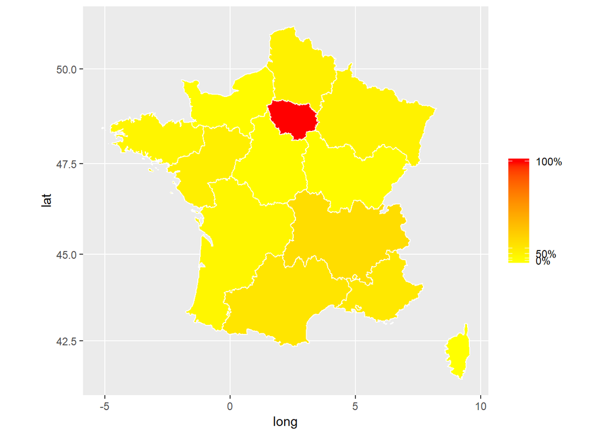

```r
Data_Met_Int_Carto<-
  ResMetBE17%>%
  filter(`code métier BMO` %in% c("M2Z90","N0Z90"))%>%
  select(REG,NOM_REG,met)%>%
  group_by(REG,NOM_REG)%>%
  summarise_at(vars(met),funs(sum))%>%
  ungroup()%>%
  mutate(pct = prop.table(met) * 100)

Region@data$CODE_SUPRA<-as.character(Region@data$CODE_SUPRA)
Region@data<-Region@data%>%
  left_join(Data_Met_Int_Carto,by=c("CODE_SUPRA"="REG"))


Region@data$id = rownames(Region@data)
Region.points<-tidy(Region,region="id")
Region.df = left_join(Region.points, Region@data, by="id")

ggplot(Region.df) +
  aes(long,lat,group=group,fill=pct) +
  geom_polygon()+
  geom_path(color="white") +
  coord_map()+
  scale_fill_continuous(name="",
                        breaks = quantile(Region$pct),
                        labels = c("0%", "","50%","","100%"),
                        low = "yellow", high = "red")
```